# week2_lab1A

## Quick Quiz

Answer: A:Height B: Age C: Weight D: Salary per year

## 2.1 Australian road fatalities

```r
library("tidyverse") # loads readr, dplyr, ggplot2, ...
bitre_link = "https://data.gov.au/data/dataset/5b530fb8-526e-4fbf-b0f6-aa24e84e4277/resource/fd646fdc-7788-4bea-a736-e4aeb0dd09a8/download/ardd_fatalities.csv"
# here's a link to a copy I took in case the above link dies.
# https://raw.githubusercontent.com/DATA2002/data/master/ardd_fatalities.csv
fdata = readr::read_csv(bitre_link)
# If you download the data file first and save it as FILE_NAME.csv
# and it is in the same folder, you can use:
# fdata = readr::read_csv("FILE_NAME.csv")
```

### Find me the unique states of this dataframe

```r
# head(fdata)
unique(as.vector(t(fdata["State"])))
```

```
## [1] "WA"  "NSW" "Qld" "Vic" "SA"  "Tas" "NT"  "ACT"
```

## 2.2 Cereal

```r
cereal = readr::read_csv("https://github.com/DATA2002/data/raw/master/Cereal.csv",
    na = "-1")
glimpse(cereal)
```

```
## Rows: 77
## Columns: 16
## $ name     <chr> "100%_Bran", "100%_Natural_Bran", "All-Bran", "All-Bran_with…
## $ mfr      <chr> "N", "Q", "K", "K", "R", "G", "K", "G", "R", "P", "Q", "G", …
## $ type     <chr> "C", "C", "C", "C", "C", "C", "C", "C", "C", "C", "C", "C", …
## $ calories <dbl> 70, 120, 70, 50, 110, 110, 110, 130, 90, 90, 120, 110, 120, …
## $ protein  <dbl> 4, 3, 4, 4, 2, 2, 2, 3, 2, 3, 1, 6, 1, 3, 1, 2, 2, 1, 1, 3, …
## $ fat      <dbl> 1, 5, 1, 0, 2, 2, 0, 2, 1, 0, 2, 2, 3, 2, 1, 0, 0, 0, 1, 3, …
## $ sodium   <dbl> 130, 15, 260, 140, 200, 180, 125, 210, 200, 210, 220, 290, 2…
## $ fiber    <dbl> 10.0, 2.0, 9.0, 14.0, 1.0, 1.5, 1.0, 2.0, 4.0, 5.0, 0.0, 2.0…
## $ carbo    <dbl> 5.0, 8.0, 7.0, 8.0, 14.0, 10.5, 11.0, 18.0, 15.0, 13.0, 12.0…
## $ sugars   <dbl> 6, 8, 5, 0, 8, 10, 14, 8, 6, 5, 12, 1, 9, 7, 13, 3, 2, 12, 1…
## $ potass   <dbl> 280, 135, 320, 330, NA, 70, 30, 100, 125, 190, 35, 105, 45, …
## $ vitamins <dbl> 25, 0, 25, 25, 25, 25, 25, 25, 25, 25, 25, 25, 25, 25, 25, 2…
## $ shelf    <dbl> 3, 3, 3, 3, 3, 1, 2, 3, 1, 3, 2, 1, 2, 3, 2, 1, 1, 2, 2, 3, …
## $ weight   <dbl> 1.00, 1.00, 1.00, 1.00, 1.00, 1.00, 1.00, 1.33, 1.00, 1.00, …
## $ cups     <dbl> 0.33, 1.00, 0.33, 0.50, 0.75, 0.75, 1.00, 0.75, 0.67, 0.67, …
## $ rating   <dbl> 68.40297, 33.98368, 59.42551, 93.70491, 34.38484, 29.50954, …
```

## 2.3 Hair and eye colour

```r
HairEyeColor
```

```
## , , Sex = Male
##
##        Eye
## Hair    Brown Blue Hazel Green
##   Black    32   11    10     3
##   Brown    53   50    25    15
##   Red      10   10     7     7
##   Blond     3   30     5     8
##
## , , Sex = Female
##
##        Eye
## Hair    Brown Blue Hazel Green
##   Black    36    9     5     2
##   Brown    66   34    29    14
##   Red      16    7     7     7
##   Blond     4   64     5     8
```

## 4 Exercises

### 4.1. Tablet devices

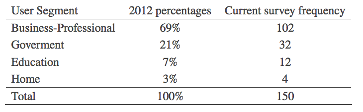

Notice how this has categorical data. Q: Does the data provide sufficient evidence to indicate that the figures obtained in the current survey agree with the percentages in 2012?

Word evidence and cross-tabulation table suggests chi-square test. Our observed data is current survey frequency and our expected data is 2012 percentages.

WTF: 2012 percentages into 2012 expected frequencies, so we can perform our chi-square test.

Null hypothesis: current survey data does agree with percentages in 2012. Alternative: current survey data does not agree with percentages in 2012.

STEPS for chi-square test (Hypothesis testing steps):

1. State null and alternative hypothesis
2. Choose level of significance
3. Find critical value
4. Find test statistic
5. Draw your conclusion.

```r
# Observed frequencies

observed_frequencies = c(102, 32, 12, 4)
# Expected probabilities
expected_probabilities = c(0.69, 0.21, 0.07, 0.03)
n = sum(observed_frequencies)
expected_frequencies = n * expected_probabilities

e_table <- data.frame(User_Segment=c("Business-Professional","Government","Education","Home"),observed_frequencies,expected_probabilities,expected_frequencies)

e_table %>% adorn_totals()
```

```
##           User_Segment observed_frequencies expected_probabilities
##  Business-Professional                  102                   0.69
##             Government                   32                   0.21
##              Education                   12                   0.07
##                   Home                    4                   0.03
##                  Total                  150                   1.00
##  expected_frequencies
##                 103.5
##                  31.5
##                  10.5
##                   4.5
##                 150.0
```

```r
# rbind(table, data.frame(User_Segment = "Total", t(colSums(table[, -1]))))
```

BUT we have a problem! In each cell of expected_frequencies, the expected frequency must be >= 5, but Home is only 4.5! So combine together to create revised table.

```r
# e_table[5,] <- c("hello", e_table[3,2:4] + e_table[4,2:4])
# e_table[5,]
# need to change to list as vector can contain only one datatype
a <- as.list(c("Education and Home", e_table[3,2:4] + e_table[4,2:4]))
e_table[3,] <- a
proper_table <- e_table[-c(4),]
proper_table
```

```
##            User_Segment observed_frequencies expected_probabilities
## 1 Business-Professional                  102                   0.69
## 2            Government                   32                   0.21
## 3    Education and Home                   16                   0.10
##   expected_frequencies
## 1                103.5
## 2                 31.5
## 3                 15.0
```

```r
obs <- proper_table[,2]
exp <-  proper_table[,4]
chi_test_statistic <- sum((obs - exp)^2/exp)
chi_test_statistic
```

```
## [1] 0.09634231
```

Our degrees of freedom for this one column contingency table is df = k -1 = 3-1=2, so with 2 degrees of freedom, we find our critical value.

```r
# To get critical value, use qchisq()
significance_level <- 0.05
df <- 2
critical_val <- qchisq(significance_level,df,lower.tail=FALSE)
chi_test_statistic > critical_val
```

```
## [1] FALSE
```

As chi_test_statistic is not greater than critical value, we do not reject the null hypothesis. Alternative, method to finding

```r
obs <- c(102, 32, 12 + 4)
exp_prob <- c(0.69, 0.21, 0.07 + 0.03)
chisq.test(obs,p=exp_prob)
```

```
##
##  Chi-squared test for given probabilities
##
## data:  obs
## X-squared = 0.096342, df = 2, p-value = 0.953
```

```r
## Find p value given our test statistic and degrees of freedom
pchisq(chi_test_statistic,2,lower.tail=FALSE)
```

```
## [1] 0.9529707
```

As p-value > 0.05, we do not reject the null hypothesis. Hence, the current data is consistent with the distribution of tablet devices in 2012.

## 4.2 Smoking rates

Of 100 randomly selected patients, there are 44 nonsmokers, 24 current smokers, 13 tobacco chewers and 19 ex-smokers. Should the researcher revise his estimates? Use 0.01 level of significance.

Null Hypothesis: Should not revise his estimates Alt Hypothesis: Research should revise his estimates

```r
obs_f_2 <- c(44,24,13,19)
expected_probs_2 <-  c(0.5, 0.2, 0.1, 0.2)
n = sum(obs_f_2)
exp_f = n * expected_probs_2
chisq.test(obs_f_2,p=expected_probs_2)
```

```
##
##  Chi-squared test for given probabilities
##
## data:  obs_f_2
## X-squared = 2.47, df = 3, p-value = 0.4807
```

As p value > 0.01, we do not reject null hypothesis. The data is consistent with the proportions estimated by the researcher.

## Australian road fatalities

```r
bitre_link = "https://data.gov.au/data/dataset/5b530fb8-526e-4fbf-b0f6-aa24e84e4277/resource/fd646fdc-7788-4bea-a736-e4aeb0dd09a8/download/ardd_fatalities.csv"
fdata = readr::read_csv(bitre_link, na = "-9", guess_max = 1e6) %>%
  janitor::clean_names()
# fdata
cdata = fdata %>%
  select(-road_user, -gender, -age, -age_group) %>%
  distinct()  %>%
  # Here we create groups based on unique crash ids. Hence we have 2 groups, as crash_id 20164024 occurs twice, each in the group.
 group_by(crash_id) %>% slice(1) %>%
    ungroup() %>%
  mutate(hour = lubridate::hour(time))
cdata
```

```
## # A tibble: 46,367 x 20
##    crash_id state month  year dayweek time  crash_type bus_involvement
##       <dbl> <chr> <dbl> <dbl> <chr>   <tim> <chr>      <chr>
##  1 19891001 NSW       6  1989 Thursd… 16:15 Multiple   No
##  2 19891002 NSW       8  1989 Wednes… 01:15 Pedestrian No
##  3 19891003 NSW       1  1989 Sunday  21:15 Multiple   No
##  4 19891004 NSW      10  1989 Friday  12:30 Pedestrian No
##  5 19891005 NSW       6  1989 Tuesday 07:45 Multiple   No
##  6 19891006 NSW       9  1989 Thursd… 01:45 Single     No
##  7 19891007 NSW       4  1989 Thursd… 10:05 Multiple   No
##  8 19891008 NSW       3  1989 Saturd… 18:00 Multiple   No
##  9 19891009 NSW      10  1989 Saturd… 05:00 Single     No
## 10 19891010 NSW       3  1989 Wednes… 08:30 Multiple   No
## # … with 46,357 more rows, and 12 more variables:
## #   heavy_rigid_truck_involvement <chr>, articulated_truck_involvement <chr>,
## #   speed_limit <chr>, national_remoteness_areas <chr>, sa4_name_2016 <chr>,
## #   national_lga_name_2017 <chr>, national_road_type <chr>,
## #   christmas_period <chr>, easter_period <chr>, day_of_week <chr>,
## #   time_of_day <chr>, hour <int>
```

```r
# slice(mtcars,1)
# mtcars
```

**1.How are missing values recorded, and why might they occur?**

The missing numeric values in the data set are denoted by ‘-9’. This might occur when police can not determine specific details about the fatality, such as the age of the killed person or the speed limit at the crash site. Text entries may contain ‘Unknown’ if police could not determine those details of the crash.

2.How many fatalities occurred since 1989? How many fatal crashes have there been since 1989? 3. What is the most common hour of the day for a fatal crash? 4. What is the most common day of the week for a fatal crash? 5. What is the most common month for a fatal crash? 6. Are fatal crashes uniformly distributed across the months of the year? Filter the data down to one year (e.g. 2019) to do this test. You should write out a full hypothesis test and make an appropriate conclusion.